# Maavara vs MERIT Hydro Spatial Match Test

```r
rm(list = ls())

knitr::opts_knit$set(root.dir = normalizePath(file.path("..", "..")))

require(pacman)
pacman::p_load(
  tidyverse,
  sf,
  janitor,
  nhdplusTools,
  units,
  ggthemes,
  patchwork
)

set.seed(350)

sf_use_s2(TRUE)

common_crs <- 4326
distance_crs <- 5070

dir_dryad <- file.path("data", "dryad_data")
dir_merit <- file.path("data", "merit_data")

path_maavara_cat <- file.path(
  dir_dryad,
  "MERIT_Hydro_CONUS_catchments",
  "MERIT_Hydro_CONUS_catchments.shp"
)

path_merit_cat <- file.path(dir_merit, "pfaf_07_cat_3sMERIT.shp")
path_merit_riv <- file.path(dir_merit, "pfaf_07_riv_3sMERIT.shp")

jemez_point <- tibble(
  name = "Jemez River reference point",
  lat = 35.766922661053755,
  lon = -106.69612666399989
) |>
  st_as_sf(coords = c("lon", "lat"), crs = common_crs)
```

# 1 Goal and Source Data

This analysis tests whether the downloaded MERIT Hydro `cat_*` and `riv_*` layers align with the MERIT Hydro catchments distributed with Maavara et al. The first pass is intentionally simple:

1. Compare COMID coverage across the Maavara catchment shapefile, downloaded MERIT catchments, and downloaded MERIT river reaches.
2. Sample 1000 Maavara COMIDs that are present in the downloaded MERIT layers and compare centroid distances.
3. Use a Jemez River HUC8 as a focused spatial test case, checking whether Maavara catchments cropped to that HUC8 are represented in the downloaded MERIT catchment and river layers.

The Maavara catchment shapefile is treated as the Maavara spatial source of truth because it contains both `COMID` and catchment geometries.

```r
maavara_cat <- read_sf(path_maavara_cat) |>
  st_set_crs(common_crs) |>
  st_transform(common_crs) |>
  clean_names() |>
  mutate(comid = as.character(comid)) |>
  select(comid, unitarea, lengthkm, geometry)

merit_cat <- read_sf(path_merit_cat) |>
  st_set_crs(common_crs) |>
  st_transform(common_crs) |>
  clean_names() |>
  mutate(comid = as.character(comid)) |>
  select(comid, any_of(c("linkno", "ds_cont_area")), geometry)

merit_riv <- read_sf(path_merit_riv) |>
  st_set_crs(common_crs) |>
  st_transform(common_crs) |>
  clean_names() |>
  mutate(comid = as.character(comid)) |>
  select(
    comid,
    any_of(c(
      "linkno",
      "dslinkno",
      "strm_order",
      "length",
      "ds_cont_area",
      "us_cont_area"
    )),
    geometry
  )

source_summary <- tibble(
  source = c("Maavara catchments", "MERIT catchments", "MERIT rivers"),
  path = c(path_maavara_cat, path_merit_cat, path_merit_riv),
  geometry_type = c(
    as.character(st_geometry_type(maavara_cat, by_geometry = FALSE)),
    as.character(st_geometry_type(merit_cat, by_geometry = FALSE)),
    as.character(st_geometry_type(merit_riv, by_geometry = FALSE))
  ),
  n_features = c(nrow(maavara_cat), nrow(merit_cat), nrow(merit_riv)),
  n_comids = c(
    n_distinct(maavara_cat$comid),
    n_distinct(merit_cat$comid),
    n_distinct(merit_riv$comid)
  ),
  duplicated_comids = c(
    sum(duplicated(maavara_cat$comid)),
    sum(duplicated(merit_cat$comid)),
    sum(duplicated(merit_riv$comid))
  )
)

source_summary
```

```
## # A tibble: 3 × 6
##   source             path    geometry_type n_features n_comids duplicated_comids
##   <chr>              <chr>   <chr>              <int>    <int>             <int>
## 1 Maavara catchments data/d… MULTIPOLYGON      175116   175116                 0
## 2 MERIT catchments   data/m… POLYGON           345832   345832                 0
## 3 MERIT rivers       data/m… LINESTRING        345832   345832                 0
```

# 2 COMID Statistics

Because the downloaded `pfaf_*` MERIT Hydro layers include more than CONUS, while Maavara is CONUS only, the main question is whether Maavara COMIDs are found in the downloaded MERIT layers.

```r
maavara_ids <- maavara_cat |>
  st_drop_geometry() |>
  distinct(comid)

merit_cat_ids <- merit_cat |>
  st_drop_geometry() |>
  distinct(comid) |>
  mutate(in_merit_cat = TRUE)

merit_riv_ids <- merit_riv |>
  st_drop_geometry() |>
  distinct(comid) |>
  mutate(in_merit_riv = TRUE)

comid_match <- maavara_ids |>
  left_join(merit_cat_ids, by = "comid") |>
  left_join(merit_riv_ids, by = "comid") |>
  mutate(
    in_merit_cat = replace_na(in_merit_cat, FALSE),
    in_merit_riv = replace_na(in_merit_riv, FALSE),
    match_class = case_when(
      in_merit_cat & in_merit_riv ~ "Maavara COMID found in cat and riv",
      in_merit_cat & !in_merit_riv ~ "Maavara COMID found in cat only",
      !in_merit_cat & in_merit_riv ~ "Maavara COMID found in riv only",
      TRUE ~ "Maavara COMID missing from cat and riv"
    )
  )

comid_match_summary <- comid_match |>
  count(match_class, sort = TRUE) |>
  mutate(prop_maavara = n / sum(n))

comid_match_summary
```

```
## # A tibble: 2 × 3
##   match_class                                 n prop_maavara
##   <chr>                                   <int>        <dbl>
## 1 Maavara COMID found in cat and riv     174702      0.998
## 2 Maavara COMID missing from cat and riv    414      0.00236
```

```r
comid_pairwise_summary <- tibble(
  comparison = c(
    "Maavara COMIDs in MERIT cat",
    "Maavara COMIDs in MERIT riv",
    "Maavara COMIDs in both MERIT cat and riv",
    "MERIT cat COMIDs in Maavara",
    "MERIT riv COMIDs in Maavara"
  ),
  n = c(
    sum(comid_match$in_merit_cat),
    sum(comid_match$in_merit_riv),
    sum(comid_match$in_merit_cat & comid_match$in_merit_riv),
    sum(merit_cat_ids$comid %in% maavara_ids$comid),
    sum(merit_riv_ids$comid %in% maavara_ids$comid)
  )
) |>
  mutate(prop_of_maavara = n / nrow(maavara_ids))

comid_pairwise_summary
```

```
## # A tibble: 5 × 3
##   comparison                                    n prop_of_maavara
##   <chr>                                     <int>           <dbl>
## 1 Maavara COMIDs in MERIT cat              174702           0.998
## 2 Maavara COMIDs in MERIT riv              174702           0.998
## 3 Maavara COMIDs in both MERIT cat and riv 174702           0.998
## 4 MERIT cat COMIDs in Maavara              174702           0.998
## 5 MERIT riv COMIDs in Maavara              174702           0.998
```

```r
missing_from_cat <- comid_match |>
  filter(!in_merit_cat)

missing_from_riv <- comid_match |>
  filter(!in_merit_riv)

list(
  first_missing_from_merit_cat = head(missing_from_cat$comid, 20),
  first_missing_from_merit_riv = head(missing_from_riv$comid, 20)
)
```

```
## $first_missing_from_merit_cat
##  [1] "71048868" "71048943" "71048729" "71048942" "71048730" "71048932"
##  [7] "71048727" "71048940" "71048930" "71048929" "71048928" "71048725"
## [13] "71048927" "71048925" "71048924" "71048726" "71048922" "71048920"
## [19] "71048918" "71048917"
##
## $first_missing_from_merit_riv
##  [1] "71048868" "71048943" "71048729" "71048942" "71048730" "71048932"
##  [7] "71048727" "71048940" "71048930" "71048929" "71048928" "71048725"
## [13] "71048927" "71048925" "71048924" "71048726" "71048922" "71048920"
## [19] "71048918" "71048917"
```

# 3 Random Centroid Distance Test

The primary spatial spot-check compares Maavara catchment centroids to downloaded MERIT catchment centroids for 1000 randomly selected shared COMIDs. A secondary diagnostic compares Maavara catchment centroids to downloaded MERIT river geometry centroids for the same style of sample.

Distances are calculated after transforming geometries to EPSG:5070.

```r
shared_cat_ids <- comid_match |>
  filter(in_merit_cat) |>
  pull(comid)

shared_riv_ids <- comid_match |>
  filter(in_merit_riv) |>
  pull(comid)

sample_cat_ids <- sample(shared_cat_ids, size = min(1000, length(shared_cat_ids)))
sample_riv_ids <- sample(shared_riv_ids, size = min(1000, length(shared_riv_ids)))

maavara_cat_centroids <- maavara_cat |>
  filter(comid %in% union(sample_cat_ids, sample_riv_ids)) |>
  st_transform(distance_crs) |>
  st_centroid() |>
  transmute(comid, maavara_geometry = geometry) |>
  st_drop_geometry()

merit_cat_centroids <- merit_cat |>
  filter(comid %in% sample_cat_ids) |>
  st_transform(distance_crs) |>
  st_centroid() |>
  transmute(comid, merit_cat_geometry = geometry) |>
  st_drop_geometry()

merit_riv_centroids <- merit_riv |>
  filter(comid %in% sample_riv_ids) |>
  st_transform(distance_crs) |>
  st_centroid() |>
  transmute(comid, merit_riv_geometry = geometry) |>
  st_drop_geometry()

cat_distances <- maavara_cat_centroids |>
  filter(comid %in% sample_cat_ids) |>
  left_join(merit_cat_centroids, by = "comid") |>
  mutate(
    distance_m = as.numeric(st_distance(
      maavara_geometry,
      merit_cat_geometry,
      by_element = TRUE
    )),
    comparison = "Maavara catchment vs MERIT catchment"
  ) |>
  select(comid, comparison, distance_m)

riv_distances <- maavara_cat_centroids |>
  filter(comid %in% sample_riv_ids) |>
  left_join(merit_riv_centroids, by = "comid") |>
  mutate(
    distance_m = as.numeric(st_distance(
      maavara_geometry,
      merit_riv_geometry,
      by_element = TRUE
    )),
    comparison = "Maavara catchment vs MERIT river"
  ) |>
  select(comid, comparison, distance_m)

centroid_distances <- bind_rows(cat_distances, riv_distances)

centroid_distance_summary <- centroid_distances |>
  group_by(comparison) |>
  summarise(
    n = n(),
    min_m = min(distance_m, na.rm = TRUE),
    p50_m = quantile(distance_m, 0.50, na.rm = TRUE),
    p90_m = quantile(distance_m, 0.90, na.rm = TRUE),
    p95_m = quantile(distance_m, 0.95, na.rm = TRUE),
    p99_m = quantile(distance_m, 0.99, na.rm = TRUE),
    max_m = max(distance_m, na.rm = TRUE),
    .groups = "drop"
  )

centroid_distance_summary
```

```
## # A tibble: 2 × 8
##   comparison                       n   min_m   p50_m  p90_m  p95_m  p99_m  max_m
##   <chr>                        <int>   <dbl>   <dbl>  <dbl>  <dbl>  <dbl>  <dbl>
## 1 Maavara catchment vs MERIT …  1000 8.86e-3 5.05e-2 7.65e5 1.09e6 1.58e6 2.30e6
## 2 Maavara catchment vs MERIT …  1000 1.72e+1 4.26e+3 7.34e5 1.08e6 1.68e6 2.18e6
```

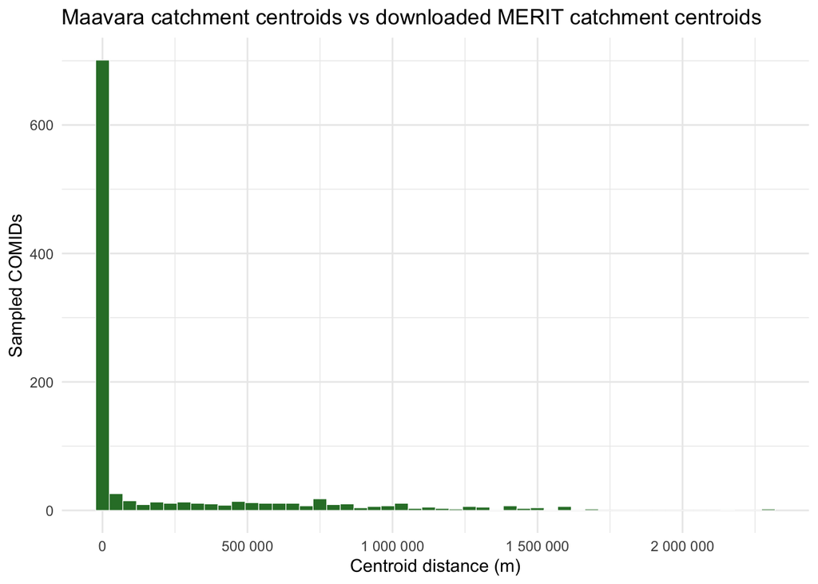

```r
cat_distance_plot <- cat_distances |>
  ggplot(aes(x = distance_m)) +
  geom_histogram(bins = 50, fill = "#2E7D32", color = "white", linewidth = 0.2) +
  scale_x_continuous(labels = scales::label_number()) +
  labs(
    x = "Centroid distance (m)",
    y = "Sampled COMIDs",
    title = "Maavara catchment centroids vs downloaded MERIT catchment centroids"
  ) +
  theme_minimal()

cat_distance_plot
```

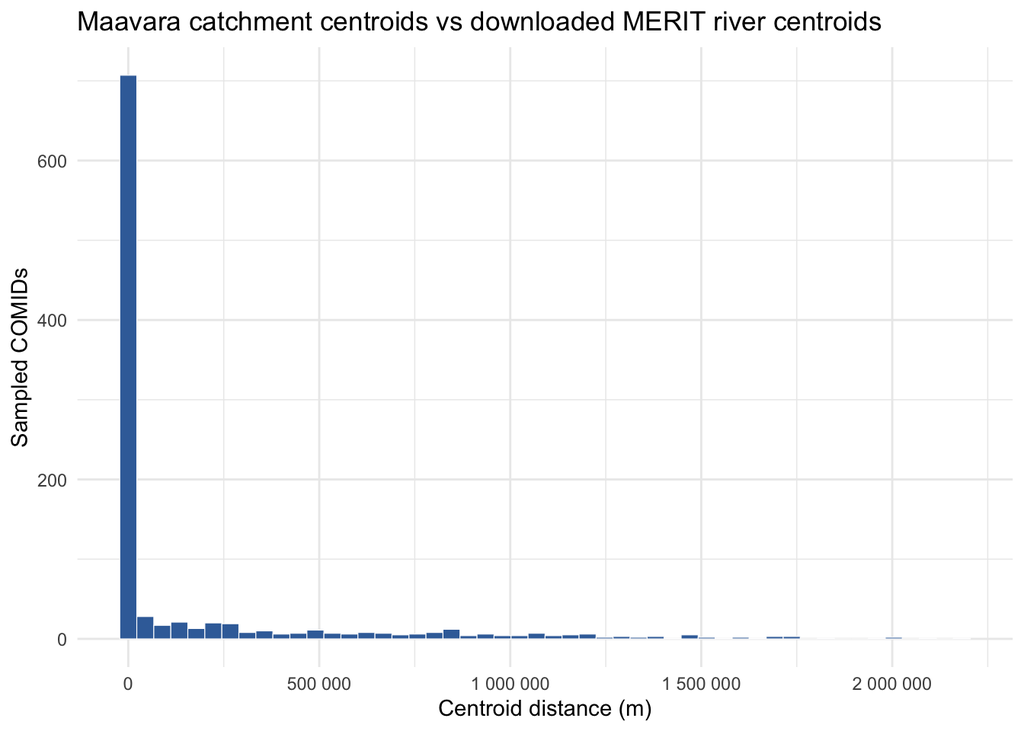

```r
riv_distance_plot <- riv_distances |>
  ggplot(aes(x = distance_m)) +
  geom_histogram(bins = 50, fill = "#3B6EA8", color = "white", linewidth = 0.2) +
  scale_x_continuous(labels = scales::label_number()) +
  labs(
    x = "Centroid distance (m)",
    y = "Sampled COMIDs",
    title = "Maavara catchment centroids vs downloaded MERIT river centroids"
  ) +
  theme_minimal()

riv_distance_plot
```

# 4 Jemez River HUC8 Test

The Jemez River test uses the provided point to identify the containing HUC8 with `nhdplusTools`, then crops Maavara catchments to that HUC8 and checks whether the cropped Maavara COMIDs are present in downloaded MERIT catchments and rivers.

```r
jemez_huc_info <- nhdplusTools::get_huc(
  AOI = jemez_point,
  type = "huc08") |>
  st_transform(common_crs) |>
  clean_names()
```

```r
jemez_boundary <- jemez_huc_info |>
  select(any_of(c("huc8", "name")), geometry)

# s2 flagged one invalid Maavara polygon loop during this spatial crop.
# The local HUC8 diagnostic uses GEOS predicates instead of spherical predicates.
sf_use_s2(FALSE)

maavara_jemez <- maavara_cat |>
  st_filter(jemez_boundary, .predicate = st_intersects)

sf_use_s2(TRUE)

jemez_ids <- maavara_jemez |>
  st_drop_geometry() |>
  distinct(comid)

merit_cat_jemez_from_ids <- merit_cat |>
  semi_join(jemez_ids, by = "comid")

merit_riv_jemez_from_ids <- merit_riv |>
  semi_join(jemez_ids, by = "comid")

jemez_match_summary <- jemez_ids |>
  left_join(
    merit_cat_ids |> select(comid, in_merit_cat),
    by = "comid"
  ) |>
  left_join(
    merit_riv_ids |> select(comid, in_merit_riv),
    by = "comid"
  ) |>
  mutate(
    in_merit_cat = replace_na(in_merit_cat, FALSE),
    in_merit_riv = replace_na(in_merit_riv, FALSE),
    match_class = case_when(
      in_merit_cat & in_merit_riv ~ "Found in cat and riv",
      in_merit_cat & !in_merit_riv ~ "Found in cat only",
      !in_merit_cat & in_merit_riv ~ "Found in riv only",
      TRUE ~ "Missing from cat and riv"
    )
  ) |>
  count(match_class, sort = TRUE) |>
  mutate(prop_jemez_maavara = n / sum(n))

jemez_match_summary
```

```
## # A tibble: 1 × 3
##   match_class              n prop_jemez_maavara
##   <chr>                <int>              <dbl>
## 1 Found in cat and riv   104                  1
```

```r
jemez_boundary_map <- jemez_boundary |>
  st_transform(distance_crs)

jemez_point_map <- jemez_point |>
  st_transform(distance_crs)

maavara_jemez_map <- maavara_jemez |>
  st_transform(distance_crs)

merit_cat_jemez_map <- merit_cat_jemez_from_ids |>
  st_transform(distance_crs)

merit_riv_jemez_map <- merit_riv_jemez_from_ids |>
  st_transform(distance_crs)
```

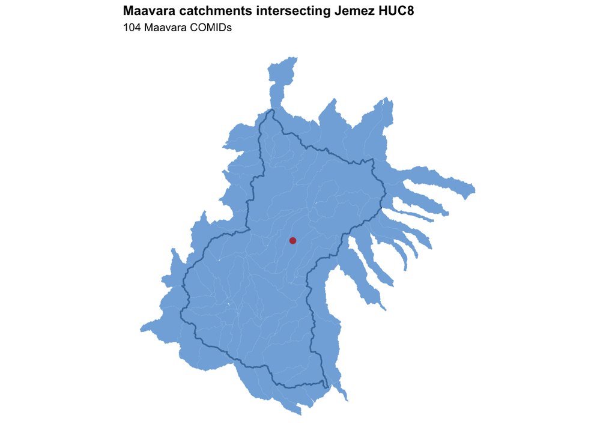

```r
p_maavara_jemez <- ggplot() +
  geom_sf(data = jemez_boundary_map, fill = NA, color = "black", linewidth = 0.6) +
  geom_sf(data = maavara_jemez_map, fill = "#5B9BD5", color = NA, alpha = 0.8) +
  geom_sf(data = jemez_point_map, color = "#B23A48", size = 2) +
  coord_sf(datum = NA) +
  labs(
    title = "Maavara catchments intersecting Jemez HUC8",
    subtitle = paste(scales::comma(nrow(maavara_jemez_map)), "Maavara COMIDs")
  ) +
  theme_map() +
  theme(
    plot.title = element_text(face = "bold"),
    plot.subtitle = element_text(size = 9)
  )

p_maavara_jemez
```

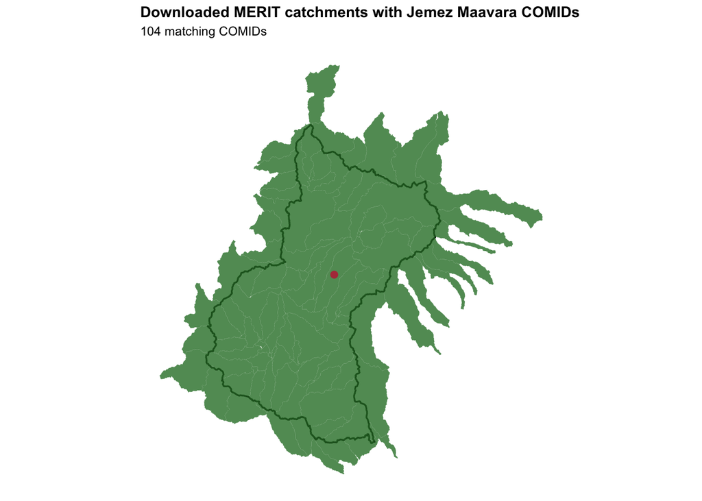

```r
p_merit_cat_jemez <- ggplot() +
  geom_sf(data = jemez_boundary_map, fill = NA, color = "black", linewidth = 0.6) +
  geom_sf(data = merit_cat_jemez_map, fill = "#2E7D32", color = NA, alpha = 0.8) +
  geom_sf(data = jemez_point_map, color = "#B23A48", size = 2) +
  coord_sf(datum = NA) +
  labs(
    title = "Downloaded MERIT catchments with Jemez Maavara COMIDs",
    subtitle = paste(scales::comma(nrow(merit_cat_jemez_map)), "matching COMIDs")
  ) +
  theme_map() +
  theme(
    plot.title = element_text(face = "bold"),
    plot.subtitle = element_text(size = 9)
  )

p_merit_cat_jemez
```

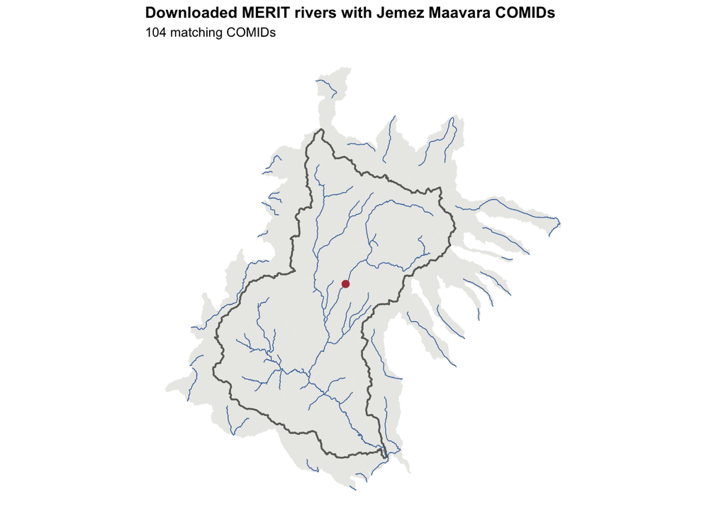

```r
p_merit_riv_jemez <- ggplot() +
  geom_sf(data = jemez_boundary_map, fill = NA, color = "black", linewidth = 0.6) +
  geom_sf(data = maavara_jemez_map, fill = "#D0D0C8", color = NA, alpha = 0.45) +
  geom_sf(data = merit_riv_jemez_map, color = "#3B6EA8", linewidth = 0.25) +
  geom_sf(data = jemez_point_map, color = "#B23A48", size = 2) +
  coord_sf(datum = NA) +
  labs(
    title = "Downloaded MERIT rivers with Jemez Maavara COMIDs",
    subtitle = paste(scales::comma(nrow(merit_riv_jemez_map)), "matching COMIDs")
  ) +
  theme_map() +
  theme(
    plot.title = element_text(face = "bold"),
    plot.subtitle = element_text(size = 9)
  )

p_merit_riv_jemez
```

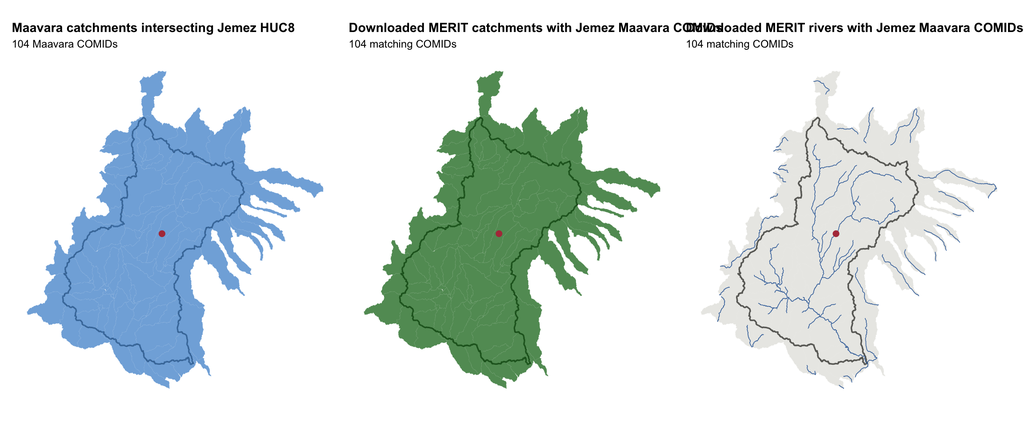

```r
p_maavara_jemez + p_merit_cat_jemez + p_merit_riv_jemez
```